# mQTL Meta-Analysis: PEG + PPMI

Your Name

2026-11-14

```r
suppressPackageStartupMessages({
  library(tidyverse)
  library(data.table)
  library(patchwork)
  library(scales)
})
```

> **How this report is produced.** All computation is done by `run_meta_mqtl.R` (run it first, ideally on a high-memory node: `Rscript run_meta_mqtl.R --cores 16`). This notebook only reads its outputs in `results/META_MQTL/{meta,qc}` and draws tables and figures. The split was made on 2026-11-14, when the fixed PEG results made the cohort files (~40M rows) and the cross-cohort intersection (~1.8M pairs) too large for an in-notebook analysis.

# 1. Configuration

```r
META_DIR <- file.path(params$meta_root, "meta")
QC_DIR   <- file.path(params$meta_root, "qc")

META_GROUPS <- list(
  cases    = c("peg1_cases",    "ppmi_cases"),
  controls = c("peg1_controls", "ppmi_controls")
)

DATASET_LABELS <- c(
  peg1_cases    = "PEG1 Cases",
  peg1_controls = "PEG1 Controls",
  peg2_cases    = "PEG2 Cases",
  ppmi_cases    = "PPMI Cases",
  ppmi_controls = "PPMI Controls"
)
DATASET_COLORS <- c(
  peg1_cases    = "#E41A1C",
  peg1_controls = "#377EB8",
  peg2_cases    = "#FF7F00",
  ppmi_cases    = "#4DAF4A",
  ppmi_controls = "#984EA3"
)
GROUP_COLORS <- c(cases = "#E41A1C", controls = "#377EB8")

fmt_n    <- function(x) format(x, big.mark = ",")
fmt_pval <- function(x) case_when(
  is.na(x)   ~ "NA",
  x < 1e-300 ~ "< 1e-300",
  x < 0.001  ~ formatC(x, format = "e", digits = 2),
  TRUE       ~ as.character(round(x, 4)))
```

## 1.1 Run information

```r
cat(readLines(file.path(QC_DIR, "run_info.txt")) %>%
      head(which(grepl("^R version", .))[1] - 1), sep = "\n")
```

```
run_meta_mqtl.R finished 2026-11-14 19:46:16
runtime: 9.7 min
settings:
List of 6
 $ out_dir     : chr "../../results/META_MQTL"
 $ max_cis_p   : num 0.001
 $ max_cis_rows: num 1.5e+07
 $ cores       : int 4
 $ engine      : chr "closed_form"
 $ qq_grid     : num 0.01

rows read per cohort:
         dataset     rows hit_cap
          <char>    <int>  <lgcl>
1:    peg1_cases  9867422   FALSE
2: peg1_controls  7949223   FALSE
3:    peg2_cases  6661736   FALSE
4:    ppmi_cases 11230706   FALSE
5: ppmi_controls  4190732   FALSE

meta groups:
  cases                    pairs=1,802,409 FDR<0.05=1,802,063
  controls                 pairs=577,396 FDR<0.05=577,251
  cases_peg2_sensitivity   pairs=1,158,733 FDR<0.05=1,158,733
```

# 2. Per-Cohort QC

> **Note on Lambda GC:** not reported. MatrixEQTL writes only associations passing its cis threshold (p < 1e-2 PEG, 1e-3 PPMI) and the script reads all cohorts at a common p < 1e-3, so lambda on this truncated tail would be meaningless. The QQ plots below use the true number of cis tests to place expected quantiles.

## 2.1 Result Summary

```r
summary_df <- fread(file.path(QC_DIR, "dataset_summary.csv"))

summary_df %>%
  mutate(label = DATASET_LABELS[dataset],
         across(c(n_assoc, n_fdr05, n_p1e5, n_p1e8, n_extreme), fmt_n),
         across(c(median_beta, max_beta), ~ round(.x, 4))) %>%
  select(label, n_assoc, n_fdr05, n_p1e5, n_p1e8, median_beta, max_beta, n_extreme) %>%
  knitr::kable(
    col.names = c("Dataset", "N assoc (p<1e-3)", "FDR<0.05", "p<1e-5", "p<1e-8",
                  "Median |β|", "Max |β|", "N |β|>1"),
    caption = paste("Per-cohort cis-mQTL summary. FDR is MatrixEQTL's per-file FDR over",
                    "all tested cis pairs (valid within cohort). β is per ALT allele",
                    "on the methylation beta-value scale, so |β| > 1 would indicate a",
                    "scaling problem."))
```

Per-cohort cis-mQTL summary. FDR is MatrixEQTL’s per-file FDR over all tested cis pairs (valid within cohort). β is per ALT allele on the methylation beta-value scale, so |β| > 1 would indicate a scaling problem.

| Dataset | N assoc (p<1e-3) | FDR<0.05 | p<1e-5 | p<1e-8 | Median \|β\| | Max \|β\| | N \|β\|>1 |
| --- | --- | --- | --- | --- | --- | --- | --- |
| PEG1 Cases | 9,867,422 | 8,360,103 | 4,730,376 | 2,633,771 | 0.0315 | 0.6675 | 0 |
| PEG1 Controls | 7,949,223 | 6,364,475 | 3,633,130 | 1,967,229 | 0.0342 | 0.6383 | 0 |
| PEG2 Cases | 6,661,736 | 4,980,393 | 2,890,232 | 1,517,482 | 0.0377 | 0.6295 | 0 |
| PPMI Cases | 11,230,706 | 8,583,873 | 4,749,259 | 2,365,291 | 0.0232 | 0.6372 | 0 |
| PPMI Controls | 4,190,732 | 1,548,936 | 1,022,012 | 354,943 | 0.0387 | 300.2187 | 48 |

```r
if (any(summary_df$max_beta > 1))
  cat("WARNING: |β| > 1 in", paste(summary_df$dataset[summary_df$max_beta > 1], collapse = ", "),
      "- check methylation scale / covariates.\n")
```

```
## WARNING: |β| > 1 in ppmi_controls - check methylation scale / covariates.
```

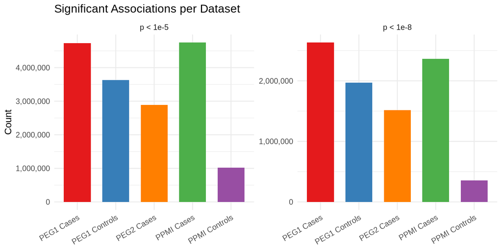

```r
summary_df %>%
  select(dataset, n_p1e5, n_p1e8) %>%
  pivot_longer(c(n_p1e5, n_p1e8), names_to = "threshold", values_to = "n") %>%
  mutate(label = DATASET_LABELS[dataset],
         threshold = factor(threshold, c("n_p1e5", "n_p1e8"), c("p < 1e-5", "p < 1e-8"))) %>%
  ggplot(aes(x = label, y = n, fill = dataset)) +
  geom_col(width = 0.7) +
  scale_fill_manual(values = DATASET_COLORS, guide = "none") +
  scale_y_continuous(labels = comma) +
  facet_wrap(~threshold, scales = "free_y") +
  labs(title = "Significant Associations per Dataset", x = NULL, y = "Count") +
  theme_minimal(base_size = 11) +
  theme(axis.text.x = element_text(angle = 30, hjust = 1))
```

## 2.2 QQ Plots

Points were computed by the script from all retained p-values and thinned to one per 0.01 cell on the −log10 scale; expected quantiles and the 95% band use the true number of cis tests per cohort.

```r
plot_qq <- function(dt, title, color) {
  n <- dt$n[1]; n_total <- dt$n_total[1]
  ggplot(dt, aes(x = exp, y = obs)) +
    geom_ribbon(aes(ymin = ci_lo, ymax = ci_hi), fill = "lightblue", alpha = 0.4) +
    geom_point(size = 0.5, alpha = 0.5, color = color) +
    geom_abline(slope = 1, intercept = 0, color = "red", linewidth = 0.7) +
    labs(title = title,
         subtitle = sprintf("n = %s%s", fmt_n(n),
                            if (n_total > n) sprintf(" (of %s cis tests)", fmt_n(n_total)) else ""),
         x = "Expected  –log₁₀(p)", y = "Observed  –log₁₀(p)") +
    theme_minimal(base_size = 11) +
    theme(plot.subtitle = element_text(size = 9, color = "grey40"))
}
```

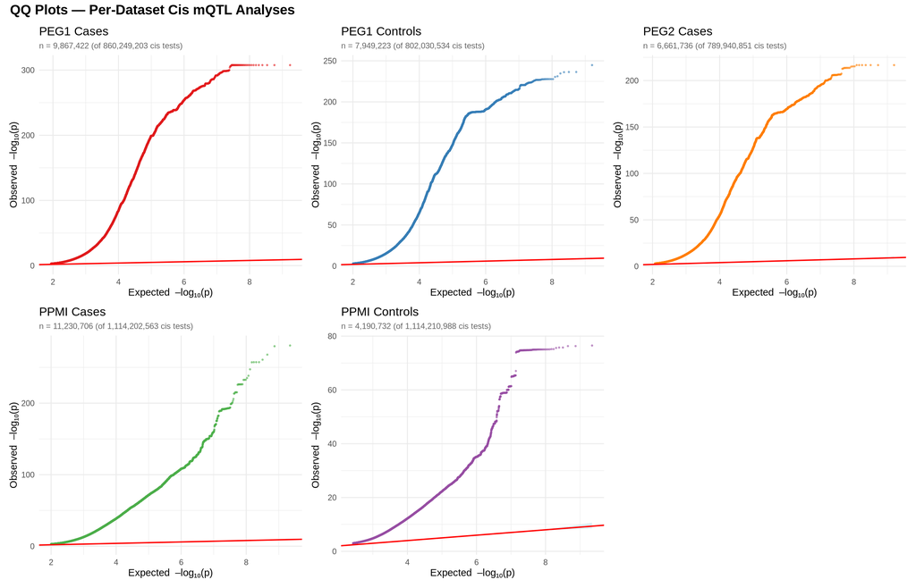

```r
qq <- fread(file.path(QC_DIR, "qq_points.csv.gz"))
wrap_plots(lapply(split(qq, qq$dataset)[names(DATASET_LABELS)], function(d)
  plot_qq(d, DATASET_LABELS[d$dataset[1]], DATASET_COLORS[d$dataset[1]])), ncol = 3) +
  plot_annotation(title = "QQ Plots — Per-Dataset Cis mQTL Analyses",
                  theme = theme(plot.title = element_text(size = 15, face = "bold")))
```

## 2.3 Effect Size Distributions

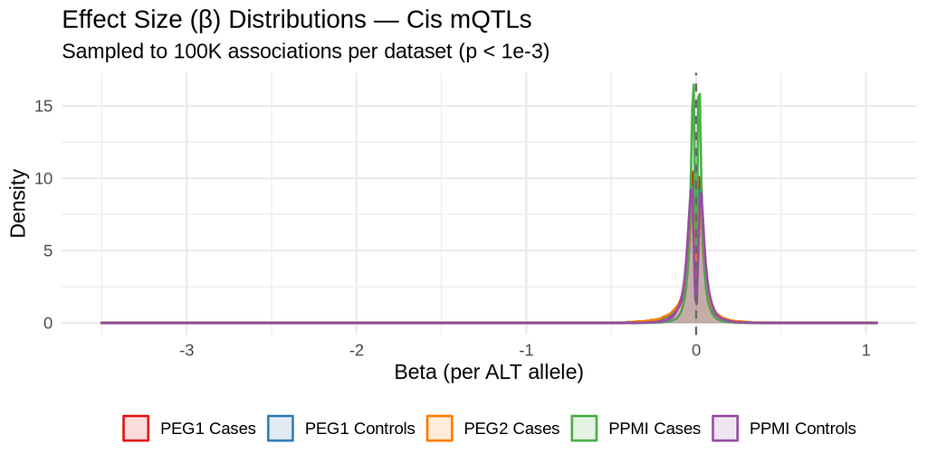

```r
fread(file.path(QC_DIR, "beta_sample.csv.gz")) %>%
  ggplot(aes(x = beta, color = dataset, fill = dataset)) +
  geom_density(alpha = 0.15, linewidth = 0.7) +
  scale_color_manual(values = DATASET_COLORS, labels = DATASET_LABELS) +
  scale_fill_manual(values = DATASET_COLORS, labels = DATASET_LABELS) +
  geom_vline(xintercept = 0, linetype = "dashed", color = "grey40") +
  labs(title = "Effect Size (β) Distributions — Cis mQTLs",
       subtitle = "Sampled to 100K associations per dataset (p < 1e-3)",
       x = "Beta (per ALT allele)", y = "Density", color = NULL, fill = NULL) +
  theme_minimal(base_size = 13) +
  theme(legend.position = "bottom")
```

# 3. Meta-Analysis Strategy

**Common-effect (fixed) inverse-variance meta-analysis** (`meta::metagen()`, or its exact closed form with `--engine closed_form`). Fixed effects suits cohorts drawn from the same population, where we want one common effect.

- **Effect size:** β from MatrixEQTL (per ALT allele in both pipelines)
- **Standard error:** SE = |β / t|
- **Pairs:** only SNP–CpG pairs present at p < 1e-3 in *all* constituent cohorts
- **Groups:** cases = PEG1 × PPMI; controls = PEG1 × PPMI; sensitivity = PEG1 × PEG2 × PPMI cases
- **Heterogeneity:** Cochran’s Q and I² (`metagen()` stores I² as a proportion; shown here as %)
- **FDR:** Benjamini–Hochberg over meta p-values within each group

```r
meta_results <- lapply(setNames(names(META_GROUPS), names(META_GROUPS)), function(g)
  fread(file.path(META_DIR, paste0(g, "_meta_results.csv.gz")),
        colClasses = list(character = c("pair_id", "snp_id", "cpg_id"))))
sens_file <- file.path(META_DIR, "cases_peg2_sensitivity_meta_results.csv.gz")
sens <- if (file.exists(sens_file)) fread(sens_file, colClasses = list(character = c("pair_id", "snp_id", "cpg_id"))) else NULL
```

# 4. Meta-Analysis Results

## 4.1 Summary

```r
all_groups <- c(meta_results, if (!is.null(sens)) list(cases_peg2_sensitivity = sens))
imap_dfr(all_groups, function(d, g) tibble(
  group     = g,
  n_pairs   = nrow(d),
  pct_fdr05 = round(100 * mean(d$FDR_BH < 0.05), 1),
  n_fdr05   = sum(d$FDR_BH < 0.05),
  n_fdr10   = sum(d$FDR_BH < 0.10),
  n_p1e5    = sum(d$meta_pval < 1e-5),
  n_p1e8    = sum(d$meta_pval < 1e-8),
  n_in_peg2 = if ("in_peg2" %in% names(d)) sum(d$in_peg2 & d$FDR_BH < 0.05) else NA,
  pct_het   = round(100 * mean(d$Q_pval < 0.05), 1))) %>%
  mutate(across(c(n_pairs, n_fdr05, n_fdr10, n_p1e5, n_p1e8, n_in_peg2), fmt_n)) %>%
  knitr::kable(
    col.names = c("Group", "Pairs", "% FDR<0.05", "FDR<0.05", "FDR<0.10",
                  "p<1e-5", "p<1e-8", "FDR<0.05 & in PEG2", "% Q p<0.05"),
    caption = paste("Meta-analysis summary. 'FDR<0.05 & in PEG2' = primary cases hits",
                    "whose pair is also present in PEG2 cases at p < 1e-3."))
```

Meta-analysis summary. ‘FDR<0.05 & in PEG2’ = primary cases hits whose pair is also present in PEG2 cases at p < 1e-3.

| Group | Pairs | % FDR<0.05 | FDR<0.05 | FDR<0.10 | p<1e-5 | p<1e-8 | FDR<0.05 & in PEG2 | % Q p<0.05 |
| --- | --- | --- | --- | --- | --- | --- | --- | --- |
| cases | 1,802,409 | 100 | 1,802,063 | 1,802,072 | 1,801,718 | 1,520,864 | 1,158,721 | 12.6 |
| controls | 577,396 | 100 | 577,251 | 577,266 | 576,985 | 509,782 | NA | 14.8 |
| cases_peg2_sensitivity | 1,158,733 | 100 | 1,158,733 | 1,158,733 | 1,158,720 | 1,158,513 | NA | 15.7 |

## 4.2 QQ Plots — Meta-Analysis

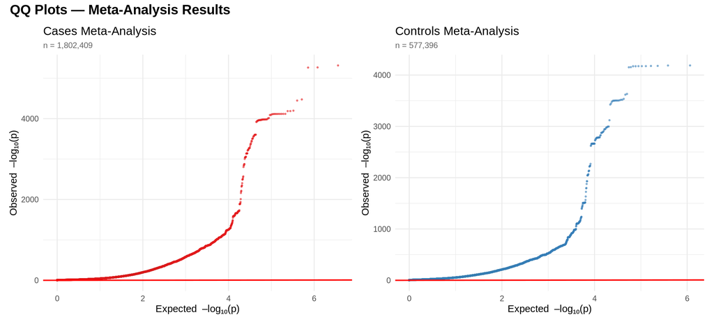

```r
mqq <- fread(file.path(QC_DIR, "meta_qq_points.csv.gz"))
wrap_plots(lapply(split(mqq, mqq$group), function(d)
  plot_qq(d, sprintf("%s Meta-Analysis", str_to_title(d$group[1])), GROUP_COLORS[d$group[1]])),
  ncol = 2) +
  plot_annotation(title = "QQ Plots — Meta-Analysis Results",
                  theme = theme(plot.title = element_text(size = 15, face = "bold")))
```

## 4.3 Top Meta-mQTLs

```r
for (g in names(META_GROUPS)) {
  ds  <- META_GROUPS[[g]]
  top <- fread(file.path(META_DIR, paste0(g, "_top20.csv")))
  cat(sprintf("\n### %s — Top 20\n\n", str_to_title(g)))
  top %>%
    mutate(meta_beta = round(meta_beta, 4), meta_se = round(meta_se, 4),
           meta_pval = fmt_pval(meta_pval), FDR_BH = fmt_pval(FDR_BH),
           I2 = round(100 * I2, 1), Q_pval = fmt_pval(Q_pval),
           across(ends_with("_beta") & !matches("^meta"), ~ round(.x, 4)),
           across(ends_with("_pvalue"), fmt_pval)) %>%
    select(snp_id, cpg_id, meta_beta, meta_se, meta_pval, FDR_BH, I2, Q_pval,
           all_of(paste0(ds, "_beta")), all_of(paste0(ds, "_pvalue"))) %>%
    knitr::kable(col.names = c("SNP", "CpG", "Meta β", "Meta SE", "Meta p", "FDR", "I² (%)", "Q p",
                               paste(DATASET_LABELS[ds], "β"), paste(DATASET_LABELS[ds], "p")),
                 caption = sprintf("Top 20 %s meta-mQTLs with per-study statistics", g)) %>%
    print()
}
```

### Cases — Top 20

Top 20 cases meta-mQTLs with per-study statistics

| SNP | CpG | Meta β | Meta SE | Meta p | FDR | I² (%) | Q p | PEG1 Cases β | PPMI Cases β | PEG1 Cases p | PPMI Cases p |
| --- | --- | --- | --- | --- | --- | --- | --- | --- | --- | --- | --- |
| 10:103048354 | cg13473803 | 0.1433 | 0.0034 | < 1e-300 | < 1e-300 | 86.7 | 0.006 | 0.1354 | 0.1543 | 9.70e-94 | 2.18e-74 |
| 10:103048540 | cg13473803 | 0.1420 | 0.0034 | < 1e-300 | < 1e-300 | 89.4 | 0.0021 | 0.1329 | 0.1543 | 5.69e-90 | 3.60e-74 |
| 10:111655790 | cg00817464 | -0.1188 | 0.0027 | < 1e-300 | < 1e-300 | 92.8 | 2.04e-04 | -0.1114 | -0.1321 | 2.70e-102 | 7.64e-75 |
| 10:111658925 | cg00817464 | -0.1182 | 0.0027 | < 1e-300 | < 1e-300 | 91.7 | 5.30e-04 | -0.1112 | -0.1309 | 4.21e-101 | 1.14e-72 |
| 10:111659454 | cg00817464 | -0.1179 | 0.0027 | < 1e-300 | < 1e-300 | 92.1 | 3.77e-04 | -0.1106 | -0.1309 | 2.29e-99 | 1.16e-72 |
| 10:111662143 | cg00817464 | -0.1182 | 0.0027 | < 1e-300 | < 1e-300 | 91.8 | 4.88e-04 | -0.1112 | -0.1310 | 4.21e-101 | 6.69e-73 |
| 10:111662938 | cg00817464 | -0.1182 | 0.0027 | < 1e-300 | < 1e-300 | 92.2 | 3.31e-04 | -0.1110 | -0.1312 | 2.23e-101 | 1.78e-73 |
| 10:111663943 | cg00817464 | -0.1181 | 0.0027 | < 1e-300 | < 1e-300 | 92.3 | 3.10e-04 | -0.1109 | -0.1312 | 1.59e-101 | 1.79e-73 |
| 10:111664595 | cg00817464 | -0.1167 | 0.0027 | < 1e-300 | < 1e-300 | 93.7 | 7.01e-05 | -0.1090 | -0.1313 | 1.14e-101 | 1.75e-73 |
| 10:111667664 | cg00817464 | -0.1180 | 0.0027 | < 1e-300 | < 1e-300 | 92.9 | 1.74e-04 | -0.1103 | -0.1315 | 7.82e-100 | 3.97e-74 |
| 10:111669132 | cg00817464 | -0.1183 | 0.0027 | < 1e-300 | < 1e-300 | 92.6 | 2.41e-04 | -0.1109 | -0.1315 | 1.60e-101 | 3.15e-74 |
| 10:111672028 | cg00817464 | -0.1181 | 0.0027 | < 1e-300 | < 1e-300 | 93.1 | 1.38e-04 | -0.1101 | -0.1316 | 8.89e-99 | 1.57e-74 |
| 10:111677201 | cg00817464 | -0.1184 | 0.0027 | < 1e-300 | < 1e-300 | 93.5 | 8.26e-05 | -0.1101 | -0.1321 | 9.52e-99 | 6.09e-76 |
| 10:111677728 | cg00817464 | -0.1186 | 0.0027 | < 1e-300 | < 1e-300 | 93.3 | 1.11e-04 | -0.1106 | -0.1321 | 1.35e-100 | 6.20e-76 |
| 10:111680388 | cg00817464 | -0.1186 | 0.0027 | < 1e-300 | < 1e-300 | 93.3 | 1.09e-04 | -0.1106 | -0.1321 | 1.31e-100 | 6.09e-76 |
| 10:111680690 | cg00817464 | -0.1184 | 0.0027 | < 1e-300 | < 1e-300 | 93.5 | 8.27e-05 | -0.1101 | -0.1321 | 9.45e-99 | 6.19e-76 |
| 10:116571281 | cg07733920 | 0.1206 | 0.0029 | < 1e-300 | < 1e-300 | 0.0 | 0.9452 | 0.1208 | 0.1204 | 1.74e-94 | 9.99e-71 |
| 10:116571796 | cg07733920 | 0.1188 | 0.0029 | < 1e-300 | < 1e-300 | 0.0 | 0.7933 | 0.1181 | 0.1197 | 1.79e-92 | 8.83e-68 |
| 10:116573423 | cg07733920 | 0.1241 | 0.0023 | < 1e-300 | < 1e-300 | 68.6 | 0.0741 | 0.1270 | 0.1180 | 1.00e-133 | 4.45e-72 |
| 10:116573902 | cg07733920 | 0.1241 | 0.0023 | < 1e-300 | < 1e-300 | 68.6 | 0.0743 | 0.1270 | 0.1180 | 9.17e-134 | 4.21e-72 |

### Controls — Top 20

Top 20 controls meta-mQTLs with per-study statistics

| SNP | CpG | Meta β | Meta SE | Meta p | FDR | I² (%) | Q p | PEG1 Controls β | PPMI Controls β | PEG1 Controls p | PPMI Controls p |
| --- | --- | --- | --- | --- | --- | --- | --- | --- | --- | --- | --- |
| 10:111655790 | cg00817464 | -0.1243 | 0.0031 | < 1e-300 | < 1e-300 | 88.0 | 0.0039 | -0.1204 | -0.1443 | 3.70e-93 | 3.98e-26 |
| 10:111658925 | cg00817464 | -0.1242 | 0.0031 | < 1e-300 | < 1e-300 | 87.9 | 0.0041 | -0.1204 | -0.1442 | 3.71e-93 | 4.20e-26 |
| 10:111659454 | cg00817464 | -0.1243 | 0.0031 | < 1e-300 | < 1e-300 | 88.0 | 0.0039 | -0.1204 | -0.1442 | 3.76e-93 | 3.94e-26 |
| 10:111662143 | cg00817464 | -0.1243 | 0.0031 | < 1e-300 | < 1e-300 | 88.0 | 0.004 | -0.1204 | -0.1442 | 3.75e-93 | 3.95e-26 |
| 10:111662938 | cg00817464 | -0.1241 | 0.0030 | < 1e-300 | < 1e-300 | 88.3 | 0.0035 | -0.1202 | -0.1443 | 2.31e-93 | 3.58e-26 |
| 10:111663943 | cg00817464 | -0.1241 | 0.0031 | < 1e-300 | < 1e-300 | 88.3 | 0.0035 | -0.1202 | -0.1443 | 2.31e-93 | 3.59e-26 |
| 10:111664595 | cg00817464 | -0.1224 | 0.0030 | < 1e-300 | < 1e-300 | 90.0 | 0.0016 | -0.1182 | -0.1443 | 2.25e-93 | 3.58e-26 |
| 10:111667664 | cg00817464 | -0.1242 | 0.0030 | < 1e-300 | < 1e-300 | 88.6 | 0.003 | -0.1202 | -0.1446 | 2.37e-93 | 2.33e-26 |
| 10:111669132 | cg00817464 | -0.1242 | 0.0030 | < 1e-300 | < 1e-300 | 88.7 | 0.003 | -0.1202 | -0.1446 | 2.31e-93 | 2.34e-26 |
| 10:111672028 | cg00817464 | -0.1245 | 0.0030 | < 1e-300 | < 1e-300 | 89.2 | 0.0024 | -0.1203 | -0.1449 | 2.32e-93 | 8.13e-27 |
| 10:111677201 | cg00817464 | -0.1245 | 0.0030 | < 1e-300 | < 1e-300 | 89.5 | 0.0021 | -0.1203 | -0.1451 | 2.30e-93 | 5.66e-27 |
| 10:111677728 | cg00817464 | -0.1245 | 0.0030 | < 1e-300 | < 1e-300 | 89.5 | 0.0021 | -0.1203 | -0.1451 | 2.34e-93 | 5.79e-27 |
| 10:111680388 | cg00817464 | -0.1245 | 0.0030 | < 1e-300 | < 1e-300 | 89.5 | 0.002 | -0.1202 | -0.1451 | 2.19e-93 | 5.76e-27 |
| 10:111680690 | cg00817464 | -0.1245 | 0.0030 | < 1e-300 | < 1e-300 | 89.5 | 0.002 | -0.1202 | -0.1451 | 2.17e-93 | 5.66e-27 |
| 10:116573423 | cg07733920 | 0.1198 | 0.0029 | < 1e-300 | < 1e-300 | 70.3 | 0.0664 | 0.1222 | 0.1077 | 3.60e-99 | 4.22e-21 |
| 10:116573902 | cg07733920 | 0.1199 | 0.0029 | < 1e-300 | < 1e-300 | 70.3 | 0.0667 | 0.1222 | 0.1077 | 3.53e-99 | 4.01e-21 |
| 10:116577161 | cg07733920 | 0.1198 | 0.0029 | < 1e-300 | < 1e-300 | 70.9 | 0.0636 | 0.1222 | 0.1075 | 3.46e-99 | 3.82e-21 |
| 10:116578539 | cg07733920 | 0.1198 | 0.0029 | < 1e-300 | < 1e-300 | 71.0 | 0.0634 | 0.1222 | 0.1075 | 3.45e-99 | 3.63e-21 |
| 10:116582560 | cg07733920 | 0.1174 | 0.0029 | < 1e-300 | < 1e-300 | 57.2 | 0.1264 | 0.1193 | 0.1073 | 2.78e-98 | 3.54e-21 |
| 10:116585109 | cg07733920 | 0.1187 | 0.0030 | < 1e-300 | < 1e-300 | 66.9 | 0.0821 | 0.1210 | 0.1073 | 3.32e-96 | 3.05e-21 |

## 4.4 Cases vs Controls Comparison

For pairs tested in both meta-analyses and FDR < 0.05 in at least one:

```r
shared <- merge(
  meta_results$cases[,    .(pair_id, beta_cases = meta_beta, fdr_cases = FDR_BH)],
  meta_results$controls[, .(pair_id, beta_ctrls = meta_beta, fdr_ctrls = FDR_BH)],
  by = "pair_id")
cat(sprintf("Pairs tested in both groups: %s\n", fmt_n(nrow(shared))))
```

```
## Pairs tested in both groups: 521,838
```

```r
sig_either <- shared[fdr_cases < 0.05 | fdr_ctrls < 0.05][
  , sig_group := fcase(fdr_cases < 0.05 & fdr_ctrls < 0.05, "Both",
                       fdr_cases < 0.05, "Cases only",
                       default = "Controls only")]
cat(sprintf("FDR<0.05 in either group: %s\n", fmt_n(nrow(sig_either))))
```

```
## FDR<0.05 in either group: 521,815
```

```r
print(table(sig_either$sig_group))
```

```
##
##          Both Controls only
##        521813             2
```

```r
cat(sprintf("Sign concordance (Both): %.3f; cor(β): %.3f\n",
            sig_either[sig_group == "Both", mean(sign(beta_cases) == sign(beta_ctrls))],
            sig_either[sig_group == "Both", cor(beta_cases, beta_ctrls)]))
```

```
## Sign concordance (Both): 1.000; cor(β): 0.992
```

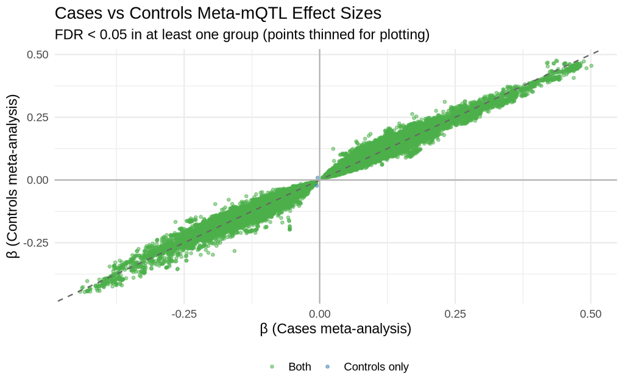

```r
# thin plotted points only (one per 0.002 β cell per group)
sig_plot <- sig_either[!duplicated(data.table(round(beta_cases / 0.002), round(beta_ctrls / 0.002), sig_group))]
ggplot(sig_plot, aes(x = beta_cases, y = beta_ctrls, color = sig_group)) +
  geom_point(alpha = 0.5, size = 1) +
  geom_abline(slope = 1, intercept = 0, linetype = "dashed", color = "grey40") +
  geom_hline(yintercept = 0, color = "grey70") +
  geom_vline(xintercept = 0, color = "grey70") +
  scale_color_manual(values = c("Both" = "#4DAF4A", "Cases only" = "#E41A1C", "Controls only" = "#377EB8")) +
  labs(title = "Cases vs Controls Meta-mQTL Effect Sizes",
       subtitle = "FDR < 0.05 in at least one group (points thinned for plotting)",
       x = "β (Cases meta-analysis)", y = "β (Controls meta-analysis)", color = NULL) +
  theme_minimal(base_size = 13) +
  theme(legend.position = "bottom")
```

## 4.5 Volcano Plots

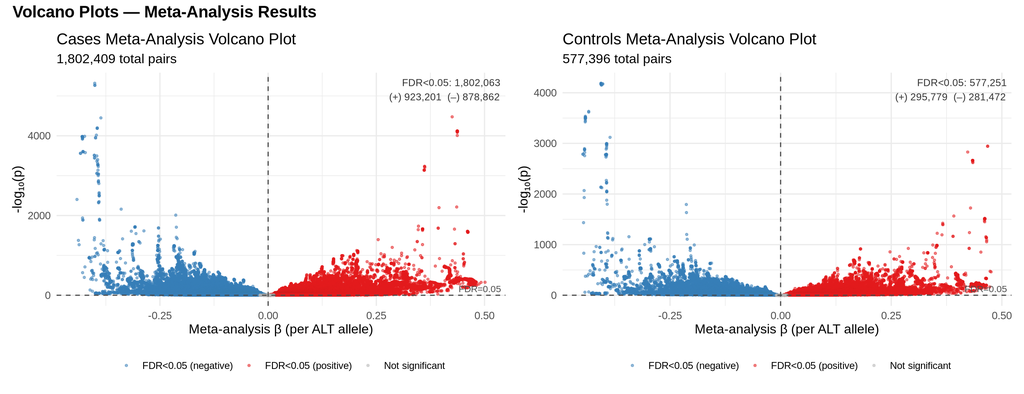

```r
sig_colors <- c("FDR<0.05 (positive)" = "#E41A1C", "FDR<0.05 (negative)" = "#377EB8",
                "Not significant" = "grey70")
volcano <- imap(meta_results, function(d, g) {
  fdr_thresh <- d[FDR_BH < 0.05, max(meta_pval)]
  # -log10 p from z: meta p underflows to 0 below ~1e-308
  dp <- d[, .(meta_beta, neg_log10_p = -(pnorm(-abs(meta_z), log.p = TRUE) + log(2)) / log(10),
              sig = fcase(FDR_BH < 0.05 & meta_beta > 0, "FDR<0.05 (positive)",
                          FDR_BH < 0.05 & meta_beta < 0, "FDR<0.05 (negative)",
                          default = "Not significant"))]
  counts <- table(factor(dp$sig, names(sig_colors)))
  # thin plotted points only; counts above use all pairs
  dp <- dp[!duplicated(data.table(round(meta_beta / 0.002), round(neg_log10_p / 0.02), sig))]
  ggplot(dp, aes(x = meta_beta, y = neg_log10_p, color = sig)) +
    geom_point(size = 0.7, alpha = 0.5) +
    geom_hline(yintercept = -log10(fdr_thresh), linetype = "dashed", color = "grey30", linewidth = 0.5) +
    geom_vline(xintercept = 0, linetype = "dashed", color = "grey30", linewidth = 0.5) +
    scale_color_manual(values = sig_colors) +
    annotate("text", x = Inf, y = -log10(fdr_thresh), label = "FDR=0.05",
             hjust = 1.1, vjust = -0.5, size = 3, color = "grey30") +
    annotate("text", x = Inf, y = Inf,
             label = sprintf("FDR<0.05: %s\n(+) %s  (–) %s", fmt_n(sum(counts[1:2])),
                             fmt_n(counts[1]), fmt_n(counts[2])),
             hjust = 1.05, vjust = 1.3, size = 3.2, color = "grey20") +
    labs(title = sprintf("%s Meta-Analysis Volcano Plot", str_to_title(g)),
         subtitle = sprintf("%s total pairs", fmt_n(nrow(d))),
         x = "Meta-analysis β (per ALT allele)", y = "-log₁₀(p)", color = NULL) +
    theme_minimal(base_size = 12) +
    theme(legend.position = "bottom", legend.text = element_text(size = 9))
})
wrap_plots(volcano, ncol = 2) +
  plot_annotation(title = "Volcano Plots — Meta-Analysis Results",
                  theme = theme(plot.title = element_text(size = 15, face = "bold")))
```

## 4.6 Heterogeneity Summary

`metagen()` returns I² as a proportion; it is converted to % here. (The pre-2026-11-14 notebook compared the proportion against 25/50/75, so its “I² > 50%” share was always 0.)

```
##
## Cases — heterogeneity among FDR<0.05 hits (n = 1,802,063):
##   Median I²:          0.0%
##   % with Q p<0.05:    12.6%
##   % with I² > 50%:    24.7%
```

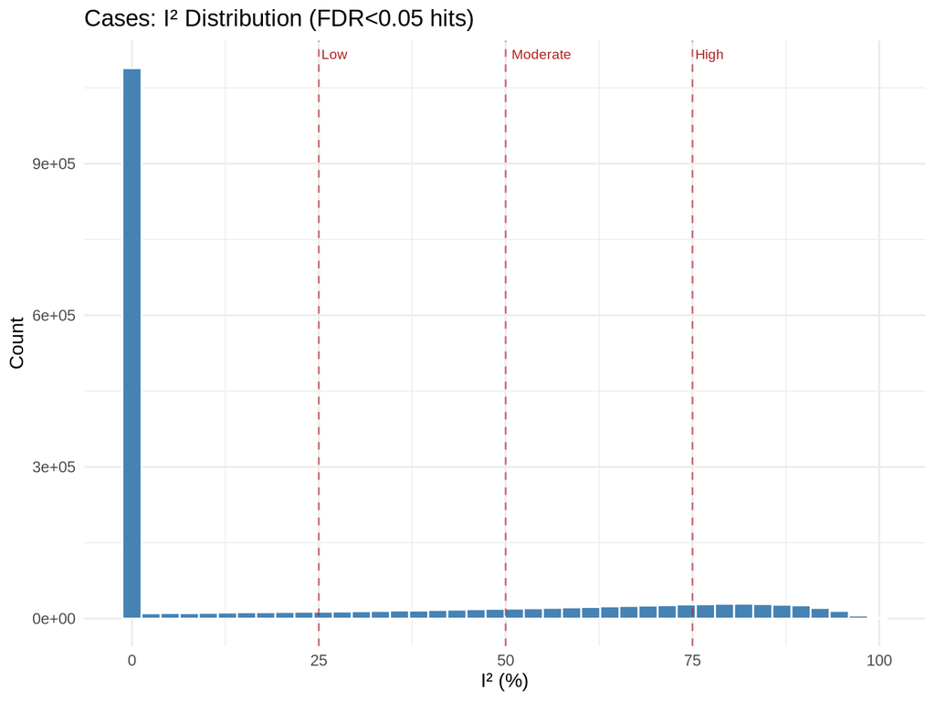

```
##
## Controls — heterogeneity among FDR<0.05 hits (n = 577,251):
##   Median I²:          0.0%
##   % with Q p<0.05:    14.8%
##   % with I² > 50%:    31.2%
```

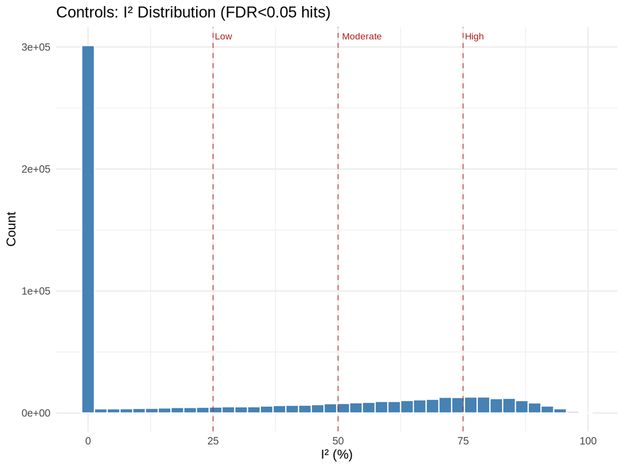

```r
for (g in names(meta_results)) {
  sig <- meta_results[[g]][FDR_BH < 0.05][, I2_pct := 100 * I2]
  if (nrow(sig) == 0) next
  cat(sprintf("\n%s — heterogeneity among FDR<0.05 hits (n = %s):\n", str_to_title(g), fmt_n(nrow(sig))))
  cat(sprintf("  Median I²:          %.1f%%\n", median(sig$I2_pct)))
  cat(sprintf("  %% with Q p<0.05:    %.1f%%\n", 100 * mean(sig$Q_pval < 0.05)))
  cat(sprintf("  %% with I² > 50%%:    %.1f%%\n", 100 * mean(sig$I2_pct > 50)))
  print(ggplot(sig, aes(x = I2_pct)) +
    geom_histogram(bins = 40, fill = "steelblue", color = "white") +
    geom_vline(xintercept = c(25, 50, 75), linetype = "dashed", color = "firebrick", alpha = 0.6) +
    annotate("text", x = c(25, 50, 75), y = Inf, label = c("Low", "Moderate", "High"),
             vjust = 2, hjust = -0.1, size = 3, color = "firebrick") +
    labs(title = sprintf("%s: I² Distribution (FDR<0.05 hits)", str_to_title(g)),
         x = "I² (%)", y = "Count") +
    theme_minimal(base_size = 12))
}
```

# 5. Output Files

Written by `run_meta_mqtl.R` (not by this notebook):

- `meta/{cases,controls}_meta_results.csv.gz` — all meta-analysed pairs (cases also carries `in_peg2`); `meta/cases_peg2_sensitivity_meta_results.csv.gz`
- `meta/{cases,controls}_sig_fdr05.csv` — FDR < 0.05 hits (input to PPMI_LONG)
- `meta/{cases,controls}_top20.csv`, `qc/*` — inputs to this report